# Lab4_Will

### 2.3 Model 2: Developed using a dataset where the numerical data was normalized

We will utilize scikit-learn's StandardScaler to normalize the continuous numerical characteristics. We will train on the normalized dataset using the previously created two-layer perceptron model, and we will assess its performance using accuracy. We will plot the loss function against the number of epochs to make sure that training converges.

```python
from sklearn.preprocessing import StandardScaler

Numerical_columns = X_train.select_dtypes(include=["number"]).columns.tolist();
# Numerical_columns.remove(['ChildPoverty','TractId'])
# normalized_values = X[Numerical_columns].values

scaler =  StandardScaler()

# Fit the scaler on the training data
X_train_scaled = X_train
X_train_scaled =  scaler.fit_transform(X_train_scaled)
#Preserve indices for Post-Modeling investigations (if needed)
X_train_scaled = pd.DataFrame(X_train_scaled, columns = Numerical_columns,index = X_train.index)

X_test_scaled = X_test
# Transform the testing data using the same parameters
X_test_scaled =  scaler.transform(X_test_scaled)
#Preserve indices for Post-Modeling investigations (if needed)
X_test_scaled = pd.DataFrame(X_test_scaled, columns = Numerical_columns,index = X_test.index)

# X_train_scaled.head()
# Check index alignment after scaling
print("Index alignment check after scaling:")
print("Training Index Match",sum(X_train_scaled.index == y_train_class.index) == len(y_train_class.index))
print("Training Index Match",sum(X_test_scaled.index == y_test_class.index) == len(y_test_class.index))
```

```
Index alignment check after scaling:
Training Index Match True
Training Index Match True
```

```
Epoch: 60/60
```

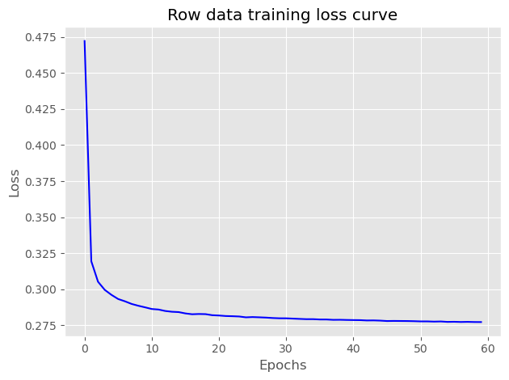

```python
vals = { 'n_hidden':50,
         'C':0.01, 'epochs':60, 'eta':0.01,
         'alpha':0.1, 'decrease_const':0.1,
         'minibatches':len(X_train)/256, 'shuffle':True, 'random_state':1}

nn_cross_norm = TLPBetterInitial(**vals)
nn_cross_norm.fit(X_train_scaled, y_train_class, print_progress=1, XY_test=(X_test_scaled, y_test_class));

cost_avgs_2 = [np.mean(x) for x in nn_cross_norm.cost_]

plt.plot(range(len(cost_avgs_2)), cost_avgs_2, color='blue')
plt.ylabel('Loss')
plt.xlabel('Epochs')
plt.title('Row data training loss curve')
plt.tight_layout()
plt.show()
```

```
=================
Cross Entropy Loss :
Resubstitution acc: 0.7432358098119435
Validation acc: 0.7372799779977998
```

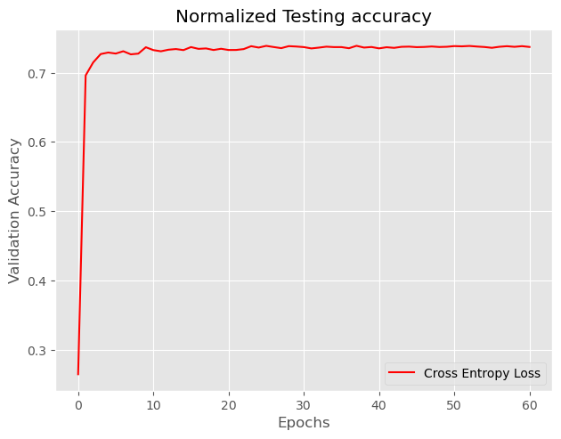

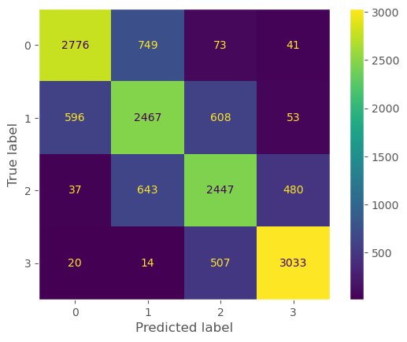

```python
print_result(nn_cross_norm,X_train_scaled,y_train_class,X_test_scaled,y_test_class,title="Cross Entropy Loss",color="red")
plt.title('Normalized Testing accuracy')
plt.show()

yhat_normalized = nn_cross_norm.predict(X_test_scaled)
Acc_normalized=accuracy_score(y_test_class,yhat_normalized)

cm = confusion_matrix(y_test_class,yhat_normalized)
disp = ConfusionMatrixDisplay(confusion_matrix=cm)
disp.plot()
plt.grid(False)

plt.show()
```